# MALASPINA SRF | 18S amplicons

Logares R. & Rubinat-Ripoll L.

24.01.2015

# 1) Data overview

Samples with less than 5000 reads are removed:

```
## MD985
##  4055
```

Table dimensions and content outline:

```
## [1] 56116   119
```

```
##          MD1013 MD1035 MD1042 MD1080 MD1100
## OTU_2      9289   2293  16285   5140   1187
## OTU_106     738     25   1497   3309   1808
## OTU_1310     84      0    111      5     23
## OTU_403      81      3    238      6     37
## OTU_139     106     23    211     58     82
```

Minimum number of reads per station:

```r
min(colSums(otu_tb18_min5000_v2))
```

```
## [1] 8764
```

Maximum number of reads per station:

```r
max(colSums(otu_tb18_min5000_v2))
```

```
## [1] 1007852
```

Identification of station with higher number of reads:

```r
amplicons_per_sample<-colSums(otu_tb18_min5000_v2)
amplicons_per_sample[which(colSums(otu_tb18_min5000_v2)>1000000)]
```

```
##  MD2516
## 1007852
```

Overall reads per sample:

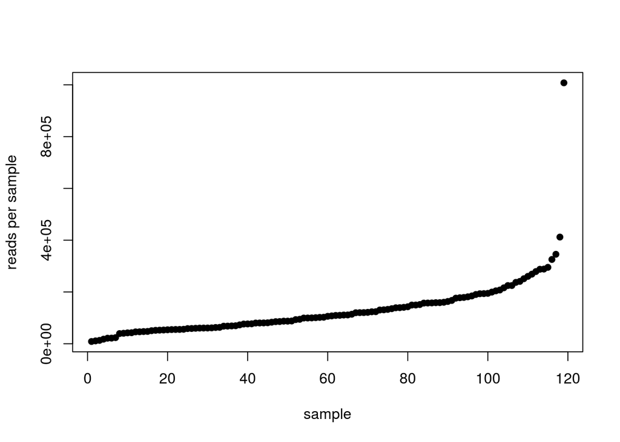

# 2) Normalization to 5000 reads per sample

Let’s normalize the original dataset by randomly subsampling 5000 reads in each station:

```r
library(vegan)
otu_tb18_min5000_v2_t<-t(otu_tb18_min5000_v2)
otu_tb18_t_ss5000<-rrarefy(otu_tb18_min5000_v2_t, 5000)
```

The normalized table shows the following dimensions and format:

```
## [1]   119 56116
```

```
##        OTU_2 OTU_106 OTU_1310 OTU_403 OTU_139
## MD1013   911      73        9       8       5
## MD1035   471       7        0       0       5
## MD1042   245      27        2       1       3
## MD1080   129      76        0       0       0
## MD1100    46      79        1       3       2
```

Its content fits with the expected normalization values (5000 reads per station):

```r
rowSums(otu_tb18_t_ss5000)
```

```
## MD1013 MD1035 MD1042 MD1080 MD1100  MD111 MD1125 MD1143 MD1176 MD1186
##   5000   5000   5000   5000   5000   5000   5000   5000   5000   5000
## MD1209 MD1222 MD1246 MD1254 MD1260 MD1293 MD1302 MD1318 MD1324 MD1331
##   5000   5000   5000   5000   5000   5000   5000   5000   5000   5000
## MD1354 MD1368 MD1398  MD141 MD1421 MD1425 MD1459 MD1475 MD1479 MD1490
##   5000   5000   5000   5000   5000   5000   5000   5000   5000   5000
## MD1517 MD1537 MD1559 MD1589 MD1607 MD1629 MD1672 MD1700 MD1724 MD1744
##   5000   5000   5000   5000   5000   5000   5000   5000   5000   5000
## MD1772 MD1798 MD1811 MD1857 MD1885 MD1887 MD1928 MD1956 MD1964  MD196
##   5000   5000   5000   5000   5000   5000   5000   5000   5000   5000
## MD2004 MD2008  MD202 MD2047 MD2051 MD2094 MD2111  MD214 MD2151 MD2155
##   5000   5000   5000   5000   5000   5000   5000   5000   5000   5000
## MD2215 MD2243 MD2247 MD2340 MD2380 MD2408 MD2436 MD2448 MD2474 MD2516
##   5000   5000   5000   5000   5000   5000   5000   5000   5000   5000
##  MD254 MD2562 MD2594 MD2624 MD2662  MD266 MD2723 MD2751 MD2761 MD2821
##   5000   5000   5000   5000   5000   5000   5000   5000   5000   5000
##  MD285 MD2864   MD28 MD2956 MD2973  MD311  MD346  MD366  MD389   MD40
##   5000   5000   5000   5000   5000   5000   5000   5000   5000   5000
##  MD417  MD439  MD458  MD486  MD506  MD528   MD52  MD550  MD575  MD591
##   5000   5000   5000   5000   5000   5000   5000   5000   5000   5000
##   MD60  MD621  MD646   MD64  MD664  MD684  MD712  MD734  MD753  MD778
##   5000   5000   5000   5000   5000   5000   5000   5000   5000   5000
##  MD806  MD834  MD854  MD876  MD897  MD916  MD940  MD962   MD98
##   5000   5000   5000   5000   5000   5000   5000   5000   5000
```

Let’s check out how many OTUs don’t appear in the new table:

```r
length(which(colSums(otu_tb18_t_ss5000)==0))
```

```
## [1] 30925
```

There are 30925 OTUs that don’t show any occurrence in the normalized data. Let’s remove them from the table and take a look at its final dimensions:

```r
otu_tb18_t_ss5000_no_cero<-otu_tb18_t_ss5000[,-(which(colSums(otu_tb18_t_ss5000)==0))]
dim(otu_tb18_t_ss5000_no_cero)
```

```
## [1]   119 25191
```

Datasets summary:

otu_tb18_min5000_v2_t –> 119 56116

otu_tb18_t_ss5000_no_cero –> 119 25191

# 3) General community analysis

## 3.1) Richness and evenness (Shannon index)

Most of the samples take Shannon Index values between 5.5 and 6:

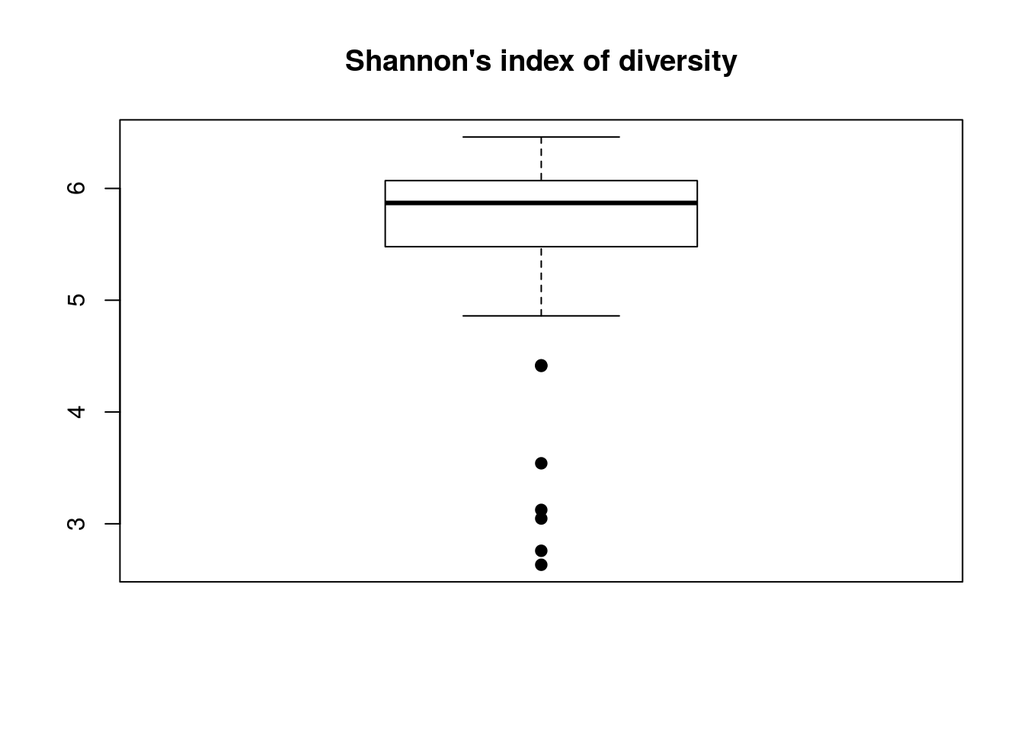

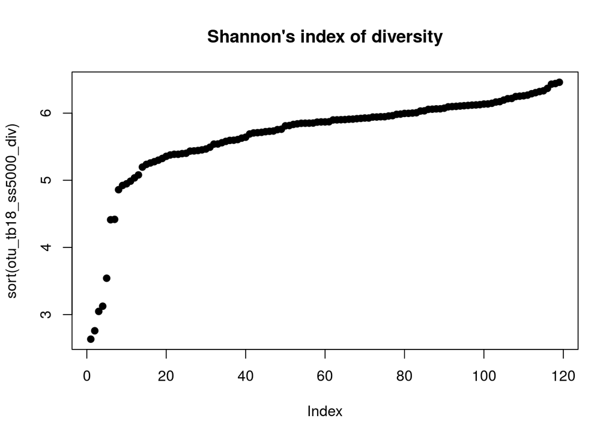

## 3.2) Richness: OTU number

Lowest number of OTUs per sample:

```
## [1] 126
```

Maximum number of OTUs per sample:

```
## [1] 1605
```

In most of the samples, we can identify between 1000 and 1300 OTUs:

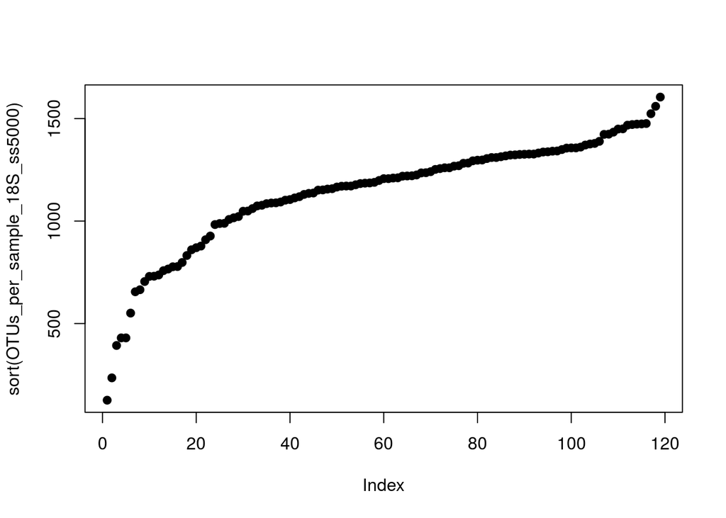

```r
plot(sort(OTUs_per_sample_18S_ss5000), pch=19)
```

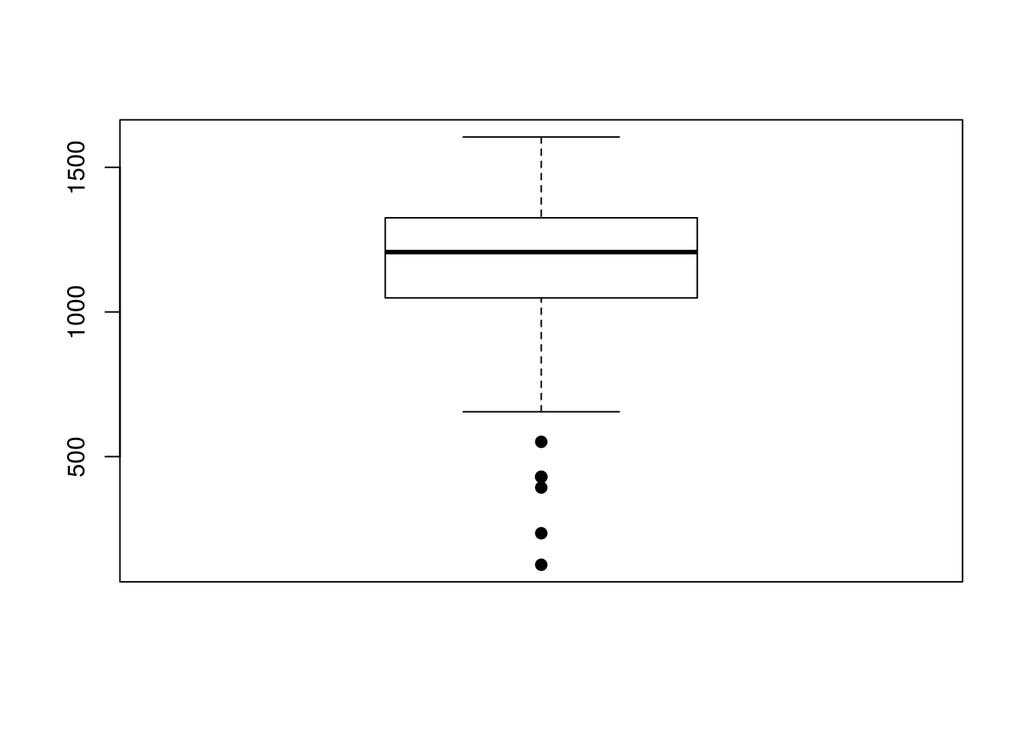

```r
boxplot(OTUs_per_sample_18S_ss5000, pch=19)
```

## 3.3) Index of evenness

### 3.3.1) Pielou’s index

```r
pielou_evenness_18S_ss5000 <- otu_tb18_ss5000_div/log(OTUs_per_sample_18S_ss5000)
```

The Pielou index (constrained between 0 and 1) takes values closer to 1 as the variation of species proportion in a sample decreases. Most of the samples get values between 0.8 and 0.9, meaning that the numerical composition of different OTUs in a sample is highly similar:

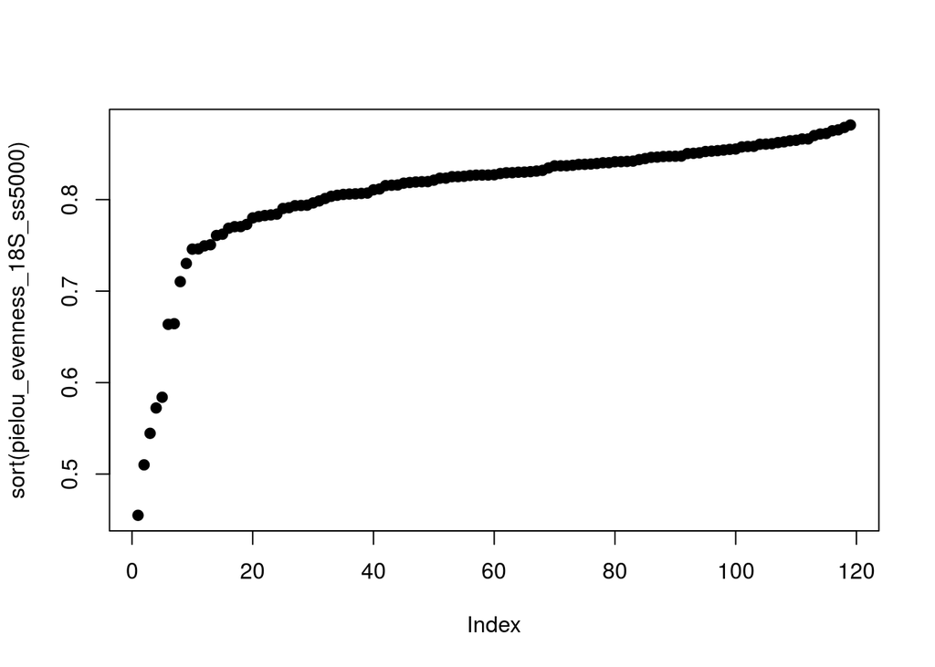

```r
plot(sort(pielou_evenness_18S_ss5000), pch=19)
```

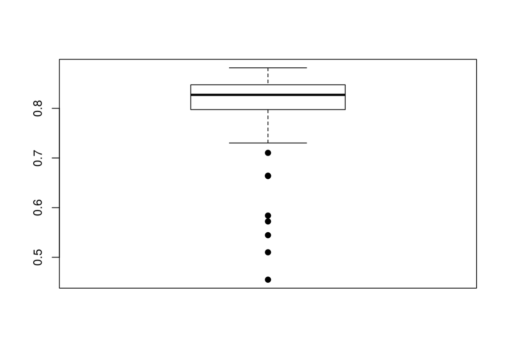

```r
boxplot(pielou_evenness_18S_ss5000, pch=19)
```

The OTU_2, with 27292 reads, is the most abundant in the overall dataset:

```r
head(sort(colSums(otu_tb18_t_ss5000_no_cero), decreasing=T), n=10L)
```

```
##  OTU_2  OTU_6 OTU_23  OTU_8 OTU_25 OTU_27  OTU_9  OTU_1 OTU_12  OTU_7
##  27292  19825   6891   6597   5667   5553   4800   4745   4447   4397
```

Most of the OTUs show very few occurrences; the plot suggests that we will probably be able to identify a significant ammount of rare otus:

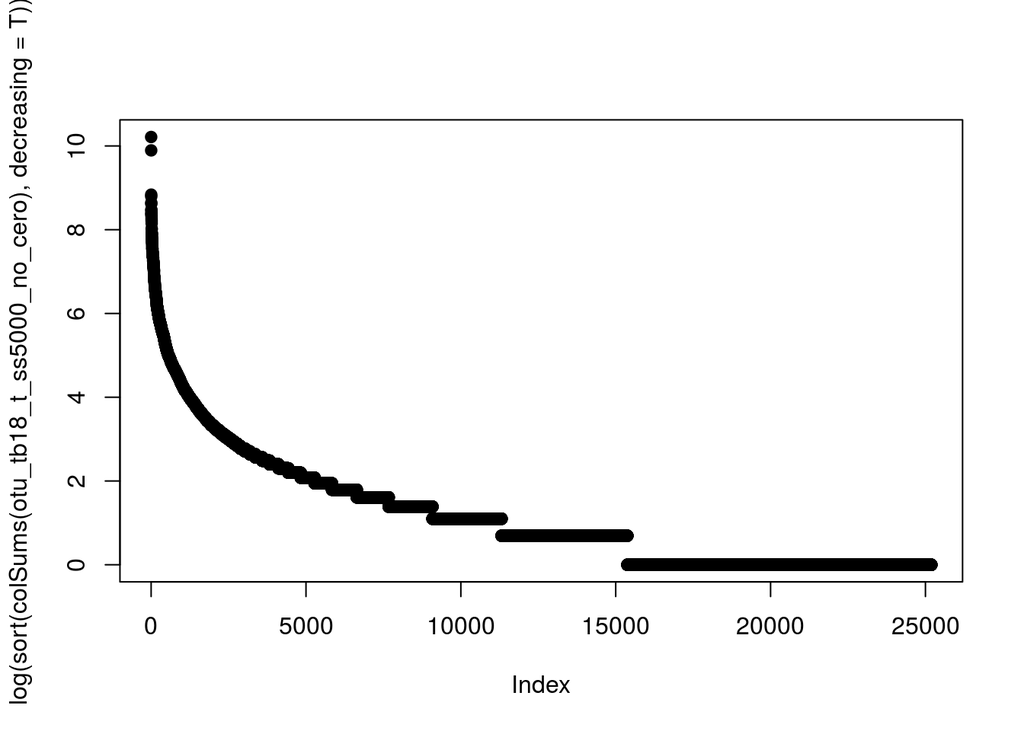

```r
plot(log(sort(colSums(otu_tb18_t_ss5000_no_cero), decreasing=T)), pch=19)
```

## 3.4) Abundance Models

### 3.4.1) Rank-Abundance or Dominance/Diversity Model (“radfit”)

The OTUs abundance distribution fits relativelly close to log-normal model.

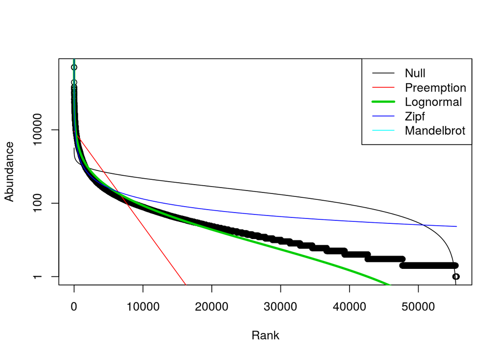

### 3.4.2) Preston’s Lognormal Model

According to Preston’s lognormal model fit into species frequencies groups, we’re missing ~3226 species:

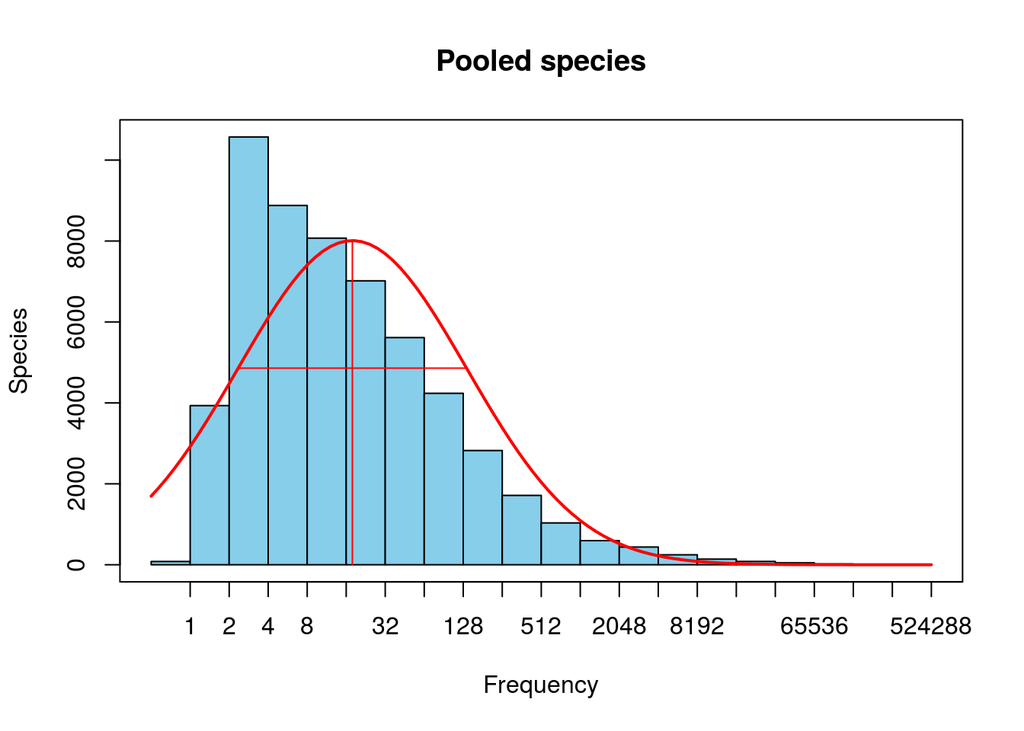

```r
otu_tb18_min5000_prestonfit<-prestonfit(colSums(otu_tb18_min5000_v2_t))
plot(otu_tb18_min5000_prestonfit, main="Pooled species")
```

```r
veiledspec(otu_tb18_min5000_prestonfit)
```

```
## Extrapolated     Observed       Veiled
##    58772.562    55547.000     3225.562
```

When computing Preston’s lognormal model fit without pooling data into groups, we seem to miss ~3055 species:

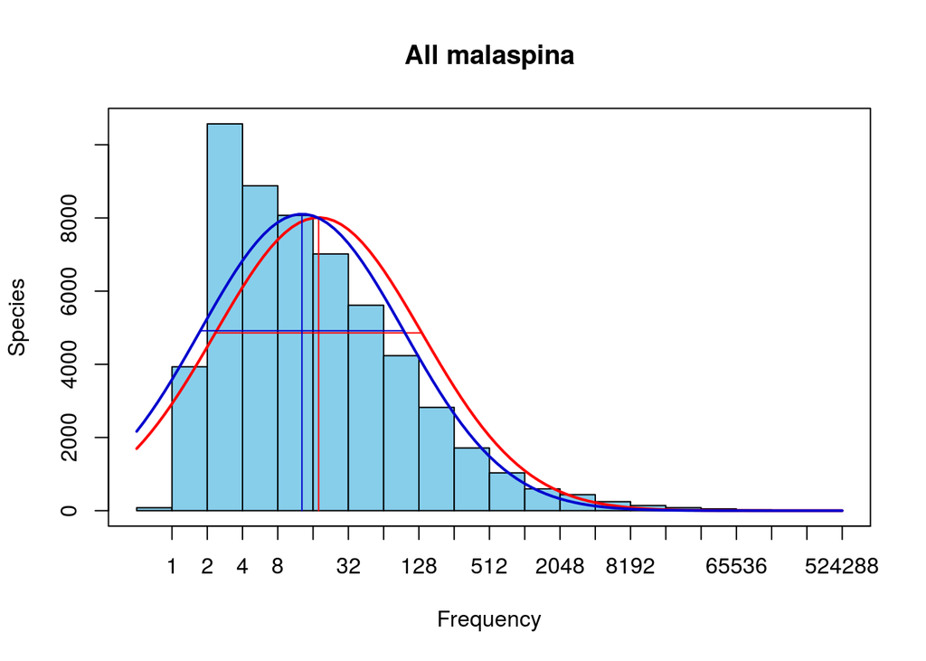

```
## Extrapolated     Observed       Veiled
##    58601.728    55547.000     3054.728
```

## 3.6) Beta diversity

### 3.6.1) Dissimilarity matrix using Bray-Curtis index:

The Bray-Curtis dissimilarity, constrained between 0 (minimum distance) and 1 (highest dissimilarity) allows us to quantify the differences between samples according to the composition and relative abundance of their OTUs. In our dataset, most of the samples pairs take dissimilarity values between between 0.7 and 0.8, meaning that their composition is substantially different.

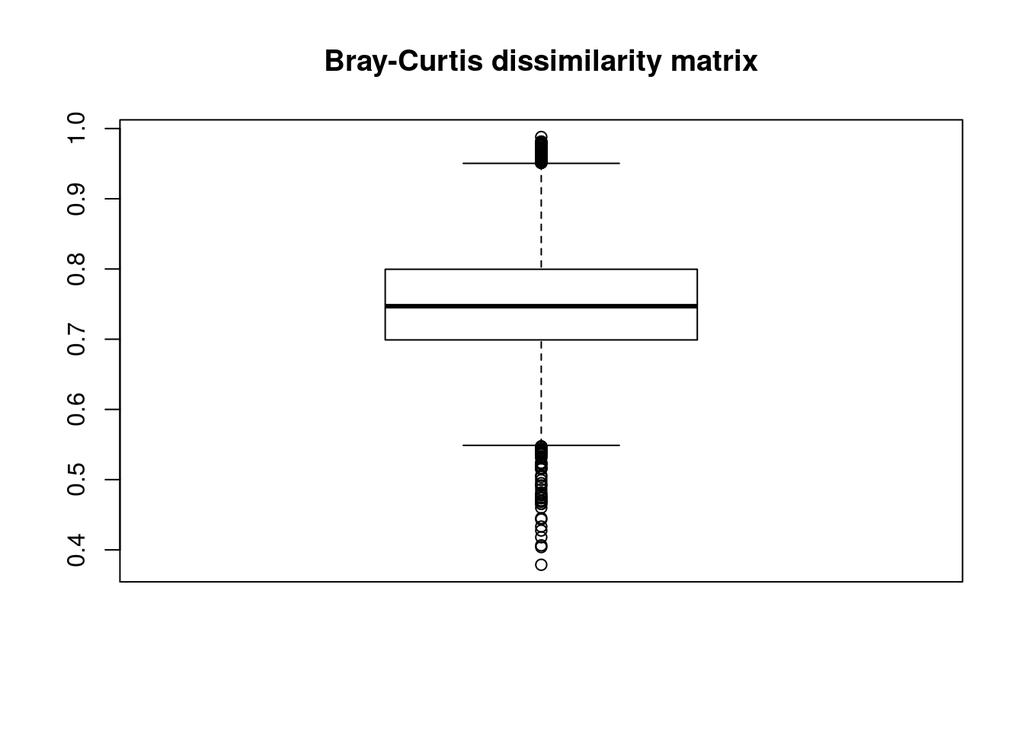

### 3.6.2) Hierarchical clustering

The only relatively evident cluster we can distinguish in the dendogram stands out in the very left side of the plot.

(To be done: assign Longhurst provinces information to each station and check if any of the central clusters is meaningful regarding to the samples’ geographical ubication)

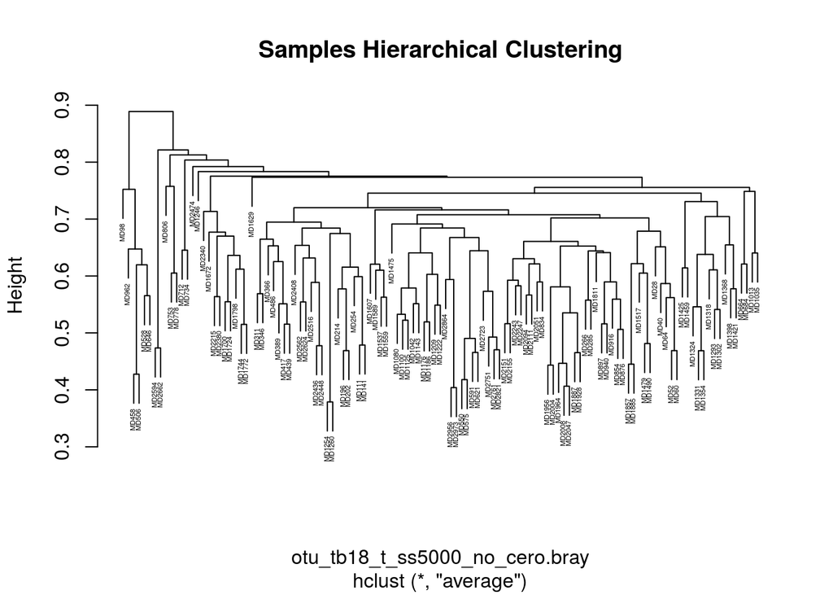

### 3.6.3) Non-metric multidimensional scaling

```
##
## Call:
## monoMDS(dist = otu_tb18_t_ss5000_no_cero.bray)
##
## Non-metric Multidimensional Scaling
##
## 119 points, dissimilarity 'bray', call 'vegdist(x = otu_tb18_t_ss5000_no_cero, method = "bray")'
##
## Dimensions: 2
## Stress:     0.2043311
## Stress type 1, weak ties
## Scores scaled to unit root mean square, rotated to principal components
## Stopped after 78 iterations: Stress nearly unchanged (ratio > sratmax)
```

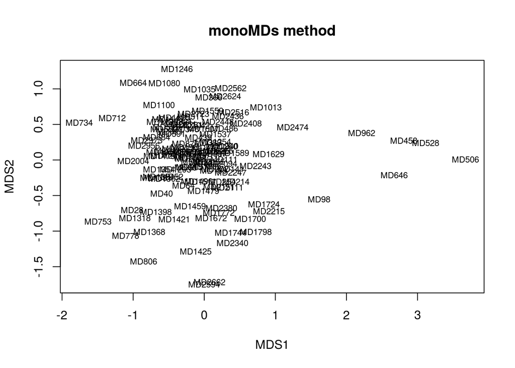

When implementing a most robut function for computing NMDS plots, the result is quiet the same:

```
## ... procrustes: rmse 0.006330118  max resid 0.06546779
## ... procrustes: rmse 0.0005368056  max resid 0.003710821
## *** Solution reached
```

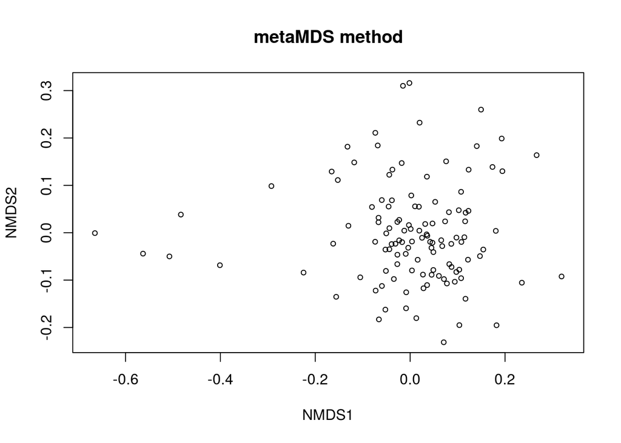

# 4) Geographical analysis

Working datasets:

1. Community matrix: otu_tb18_t_ss5000_no_cero

```r
dim(otu_tb18_t_ss5000_no_cero)
```

```
## [1]   119 25191
```

```r
otu_tb18_t_ss5000_no_cero[1:5, 1:5]
```

```
##        OTU_2 OTU_106 OTU_1310 OTU_403 OTU_139
## MD1013   911      73        9       8       5
## MD1035   471       7        0       0       5
## MD1042   245      27        2       1       3
## MD1080   129      76        0       0       0
## MD1100    46      79        1       3       2
```

2. Community Bray-Curtis: otu_tb18_t_ss5000_no_cero.bray

```r
otu_tb18_t_ss5000_no_cero.bray<-as.matrix(otu_tb18_t_ss5000_no_cero.bray)
```

3. Stations distances in km: geo_distances_MP_18S_ss5000

```r
dim(geo_distances_MP_18S_ss5000)
```

```
## [1] 119 119
```

Communities quickly change their composition across geographical distances:

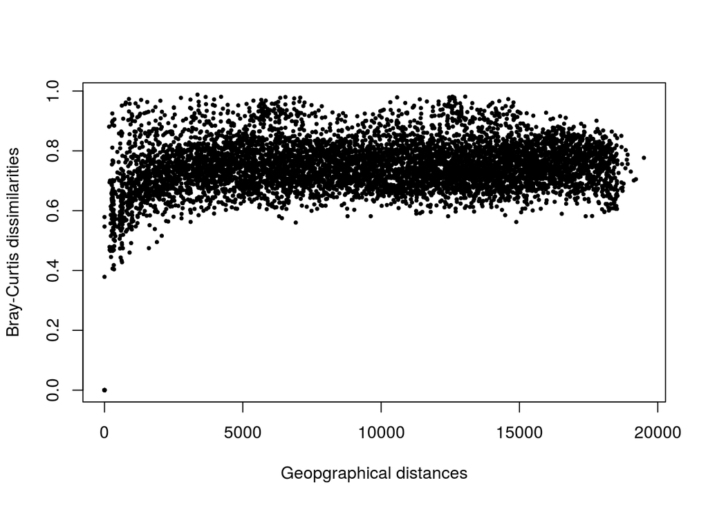

```r
plot(geo_distances_MP_18S_ss5000, otu_tb18_t_ss5000_no_cero.bray, pch=19, cex=0.4, xlab="Geopgraphical distances", ylab="Bray-Curtis dissimilarities")
```

## 4.1) Mantel correlograms

Mantel statistic is -significantlly- so low, meaning that the correlation between samples dissimilarity and geographical distances is weak.

```r
mantel(geo_distances_MP_18S_ss5000, otu_tb18_t_ss5000_no_cero.bray)
```

```
##
## Mantel statistic based on Pearson's product-moment correlation
##
## Call:
## mantel(xdis = geo_distances_MP_18S_ss5000, ydis = otu_tb18_t_ss5000_no_cero.bray)
##
## Mantel statistic r: 0.1261
##       Significance: 0.001
##
## Upper quantiles of permutations (null model):
##    90%    95%  97.5%    99%
## 0.0205 0.0277 0.0336 0.0449
## Permutation: free
## Number of permutations: 999
```

Maximum distance between samples:

```
## [1] 19500.19
```

Minimum distance between samples:

```
## [1] 0
```

Correlograms:

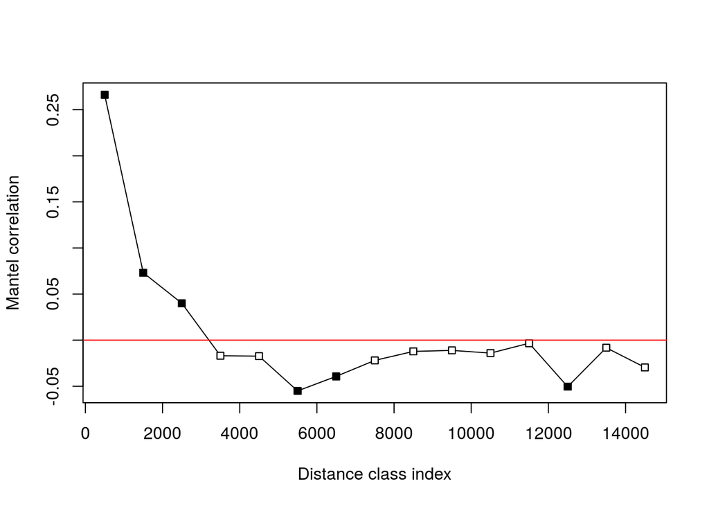

```r
MP_18s_ss5000_mantel_correl_by_1000km<-mantel.correlog(otu_tb18_t_ss5000_no_cero.bray, D.geo=geo_distances_MP_18S_ss5000, break.pts=seq(0,20000, by=1000))
plot(MP_18s_ss5000_mantel_correl_by_1000km)
```

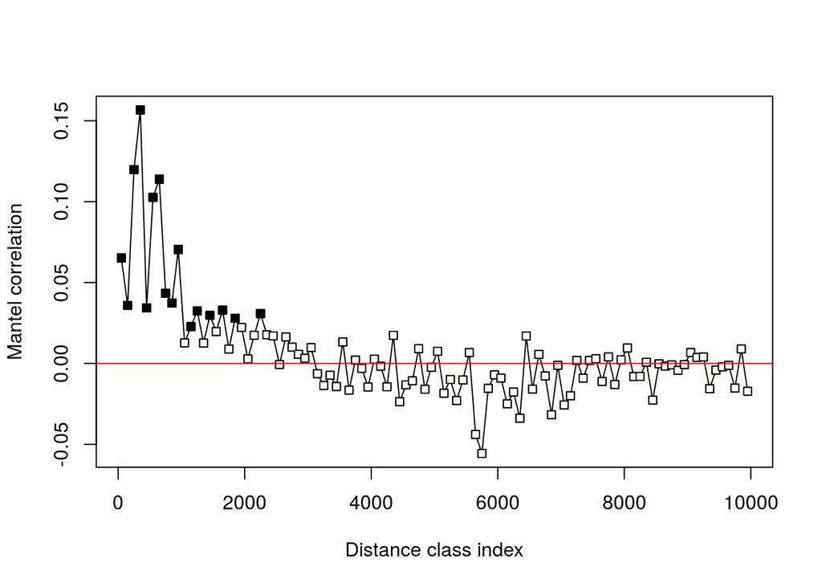

```r
MP_18s_ss5000_mantel_correl_by_100km<-mantel.correlog(otu_tb18_t_ss5000_no_cero.bray, D.geo=geo_distances_MP_18S_ss5000, break.pts=seq(0,20000, by=100))
plot(MP_18s_ss5000_mantel_correl_by_100km)
```

# 5) Abundance vs. occurence

In the following plot, we can appreciate the OTUs distribution according to their percentage of occurence and relative abundance. The red line keeps up OTUs that occur in more than 80% of the samples, the green line limits regionally rare OTUs (< 0.001%), and the blue one restricts regionally abundant OTUs (> 0.1%).

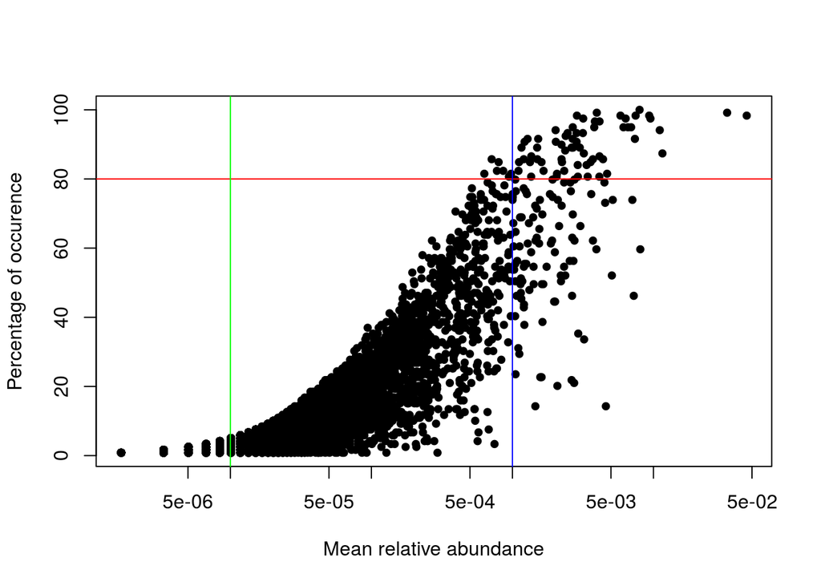

Regionally abundant OTUs (relative abundance over 0.1%):

```
##           mean_rabund perc_occur
## OTU_2     0.045868908   98.31933
## OTU_6     0.033319328   99.15966
## OTU_23    0.011581513   87.39496
## OTU_8     0.011087395   94.11765
## OTU_25    0.009524370   97.47899
## OTU_27    0.009332773   98.31933
## OTU_9     0.008067227   59.66387
## OTU_1     0.007974790  100.00000
## OTU_12    0.007473950   98.31933
## OTU_7     0.007389916   91.59664
## OTU_20    0.007253782   46.21849
## OTU_14696 0.007089076   73.94958
## OTU_13    0.006946218   94.95798
## OTU_4     0.006596639   94.95798
## OTU_11    0.006352941   97.47899
## OTU_24    0.006131092   94.95798
## OTU_18    0.005838655   98.31933
## OTU_3     0.005144538   73.94958
## OTU_34    0.005072269   52.10084
## OTU_21    0.004692437   81.51261
## OTU_119   0.004600000   14.28571
## OTU_5     0.004546218   73.10924
## OTU_22    0.004492437   78.99160
## OTU_26    0.004389916   85.71429
## OTU_45    0.004146218   96.63866
## OTU_17    0.004144538   86.55462
## OTU_10    0.004134454   80.67227
## OTU_64    0.003964706   99.15966
## OTU_58    0.003939496   59.66387
## OTU_19    0.003843697   96.63866
## OTU_40    0.003803361   94.95798
## OTU_70    0.003724370   62.18487
## OTU_36    0.003719328   85.71429
## OTU_106   0.003621849   75.63025
## OTU_50    0.003583193   84.87395
## OTU_14    0.003418487   80.67227
## OTU_28    0.003357983   84.03361
## OTU_44    0.003223529   33.61345
## OTU_5618  0.003208403   87.39496
```

[output cut: 108 more lines]

```
## OTU_113   0.001080672   56.30252
## OTU_133   0.001072269   46.21849
## OTU_7573  0.001057143   76.47059
## OTU_152   0.001052101   64.70588
## OTU_214   0.001052101   23.52941
## OTU_141   0.001048739   50.42017
## OTU_192   0.001047059   79.83193
## OTU_151   0.001047059   55.46218
## OTU_1819  0.001045378   40.33613
## OTU_163   0.001028571   53.78151
## OTU_165   0.001018487   60.50420
## OTU_140   0.001015126   67.22689
## OTU_338   0.001005042   74.78992
## OTU_117   0.001003361   75.63025
## OTU_11833 0.001001681   73.94958
```

```r
dim(tb18_ss5000_abundant_sorted)
```

```
## [1] 162   2
```

Proportion of regionally abundant OTUs (%):

```
## [1] 0.6430868
```

Cosmopolitan OTUs (relative abundance over 0.1% and occurence in more than 80% of samples):

```
##           mean_rabund perc_occur
## OTU_1     0.007974790  100.00000
## OTU_6     0.033319328   99.15966
## OTU_64    0.003964706   99.15966
## OTU_2     0.045868908   98.31933
## OTU_27    0.009332773   98.31933
## OTU_12    0.007473950   98.31933
## OTU_18    0.005838655   98.31933
## OTU_39    0.002867227   98.31933
## OTU_25    0.009524370   97.47899
## OTU_11    0.006352941   97.47899
## OTU_55    0.003176471   97.47899
## OTU_45    0.004146218   96.63866
## OTU_19    0.003843697   96.63866
## OTU_13    0.006946218   94.95798
## OTU_4     0.006596639   94.95798
## OTU_24    0.006131092   94.95798
## OTU_40    0.003803361   94.95798
## OTU_29    0.002678992   94.95798
## OTU_8     0.011087395   94.11765
## OTU_11454 0.002023529   94.11765
## OTU_31    0.003159664   93.27731
## OTU_33    0.002850420   93.27731
## OTU_49    0.002462185   93.27731
## OTU_75    0.002386555   92.43697
## OTU_7     0.007389916   91.59664
## OTU_72    0.002675630   91.59664
## OTU_67    0.001522689   91.59664
## OTU_243   0.001280672   91.59664
## OTU_35799 0.002850420   90.75630
## OTU_78    0.002031933   90.75630
## OTU_1136  0.001220168   90.75630
## OTU_66    0.002228571   89.91597
## OTU_42    0.003003361   89.07563
## OTU_37    0.002692437   89.07563
## OTU_65    0.002626891   89.07563
## OTU_121   0.001497479   89.07563
## OTU_188   0.001159664   89.07563
## OTU_71    0.002368067   88.23529
## OTU_23    0.011581513   87.39496
```

[output cut: 10 more lines]

```
## OTU_126   0.001608403   84.87395
## OTU_88    0.001332773   84.87395
## OTU_131   0.001114286   84.87395
## OTU_28    0.003357983   84.03361
## OTU_81    0.002905882   84.03361
## OTU_85    0.002329412   82.35294
## OTU_57    0.001662185   82.35294
## OTU_125   0.001104202   82.35294
## OTU_21    0.004692437   81.51261
## OTU_54    0.002070588   81.51261
## OTU_10    0.004134454   80.67227
## OTU_14    0.003418487   80.67227
## OTU_38    0.002912605   80.67227
## OTU_76    0.002057143   80.67227
## OTU_112   0.001357983   80.67227
```

```r
dim(otu_tb18_ss5000_cosmop_sorted)
```

```
## [1] 64  2
```

Proportion of cosmopolitan OTUs (%):

```
## [1] 0.254059
```

Number and proportion (%) of rare OTUs:

```r
dim(otu_tb18_ss5000_rabund_percoccur[otu_tb18_ss5000_rabund_percoccur$mean_rabund < 0.00001 & otu_tb18_ss5000_rabund_percoccur$mean_rabund >0,])
```

```
## [1] 18551     2
```

```
## [1] 73.64138
```